# Machine Learning for text data

# Before we start

Grab the [example code](https://raw.githubusercontent.com/Neilblund/GVPT628Fall2025/refs/heads/main/Week%2013/LDA_example.R) and run the first section to start downloading some packages.

Short link: https://tinyurl.com/2rn5fdcx

# Goals

We’ll look at some approaches to topic modeling: unsupervised models for identifying themes in a collection of documents.

1. Overview of the bag-of-words approach to modeling text as data.
2. Latent Dirichlet Allocation (LDA) and some of its variants.
3. Newer topic models based on text embeddings and neural networks.

## Use-cases for text analysis

- Categorizing open-ended survey responses (Roberts et al. 2014)
- Identifying party positions from manifesto texts (Koljonen et al. 2022)
- Tracking sentiment in newspaper coverage of the economy (Watanabe 2021)

## Problem

I’ve got around ~6,000 bill summaries from the Congress.gov API. I have some metadata about each one, but I want to be able to summarize their content and group similar bills together.

> This bill designates the facility of the United States Postal Service located at 107 North Hoyne Avenue in Fritch, Texas, as the “Chief Zeb Smith Post Office”.

> This bill changes certain terms that are used by the Social Security Administration (SSA) to describe the ages at which a worker may claim Social Security retirement benefits…

> This bill broadens the authority for certain law enforcement officers to carry concealed firearms across state lines…

> This bill prohibits the use of federal funds for diversity, equity, and inclusion activities (e.g., training) of the Armed Forces…

## Topic modeling as unsupervised learning

- Recall that unsupervised learning is a method for identifying structures in unlabeled data.
- Categorizing documents by topic is an intuitive analog for text data.

## Topic modeling as unsupervised learning

In a previous class, we used K-means clustering to identify groups of similar observations. We *could* apply the same method here, if we can conver this text data into numeric data.

### Texts as numbers

A common approach here would be to do the following:

1. **Tokenize** each text (split into units like words or sentences)
2. **Normalize/filter** the tokens (for instance, by removing punctuation or lower casing, or we might go further and chop off inflections and tense)
3. **Vectorize** the texts (in this case, just count occurrences of each term in each document)

| doc_id | this | bill | designates | the | … | equity | and | inclusion | activities | e.g | training | armed | forces |
| --- | --- | --- | --- | --- | --- | --- | --- | --- | --- | --- | --- | --- | --- |
| text1 | 1 | 1 | 1 | 3 | … | 0 | 0 | 0 | 0 | 0 | 0 | 0 | 0 |
| text2 | 1 | 1 | 0 | 2 | … | 0 | 0 | 0 | 0 | 0 | 0 | 0 | 0 |
| text3 | 1 | 1 | 0 | 1 | … | 0 | 0 | 0 | 0 | 0 | 0 | 0 | 0 |
| text4 | 1 | 1 | 0 | 2 | … | 1 | 1 | 1 | 1 | 1 | 1 | 1 | 1 |

The result is a document-term-matrix (DTM) with one column per term and one row per document. This is the basic building block for most text analysis tasks.

### Try it out

- Code for the pre-processing steps is in sections 1 and 2 of [this R script](https://raw.githubusercontent.com/Neilblund/GVPT628Fall2025/refs/heads/main/Week%2013/LDA_example.R).

### Texts as numbers

We *can* use K-means clustering on this matrix, but we might get some weird results.

| doc_id | this | bill | designates | the | … | equity | and | inclusion | activities | e.g | training | armed | forces |
| --- | --- | --- | --- | --- | --- | --- | --- | --- | --- | --- | --- | --- | --- |
| text1 | 1 | 1 | 1 | 3 | … | 0 | 0 | 0 | 0 | 0 | 0 | 0 | 0 |
| text2 | 1 | 1 | 0 | 2 | … | 0 | 0 | 0 | 0 | 0 | 0 | 0 | 0 |
| text3 | 1 | 1 | 0 | 1 | … | 0 | 0 | 0 | 0 | 0 | 0 | 0 | 0 |
| text4 | 1 | 1 | 0 | 2 | … | 1 | 1 | 1 | 1 | 1 | 1 | 1 | 1 |

## What makes a good topic model?

A good topic model should:

- Ignore arbitrary features like document length.
- Make it easy to identify similar documents, even if they use different words to express the same idea.
- Allow for the possibility that a document has more than one topic.
- Generate interpret-able clusters of topics.

Latent Dirichlet Allocation is one widely used method for topic modeling that fits the criteria listed above

## The Dirichlet Distribution

- The Dirichlet distribution is a probability distribution for the proportions/probabilities of multinomial outcomes.
- It has a single parameter $\alpha$ that is a positive vector of length “K” that controls the concentration of the distribution around each of the K possible outcomes.

## The Dirichlet Distribution

- We could use a Dirichlet distribution to model the process of manufacturing imperfect dice.

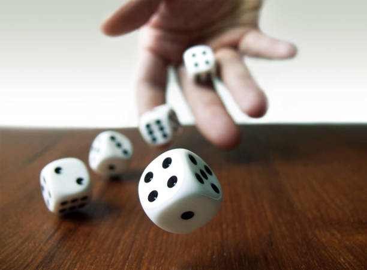

## The Dirichlet Distribution

- We could use a Dirichlet distribution to model the process of manufacturing imperfect dice.
- The probability of any side will always be greater than 0 and all six sides will sum to 1, but there will be random variability in how uniformly they’re distributed.

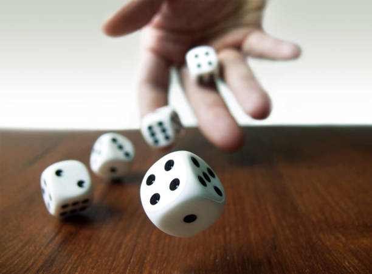

## The Dirichlet Distribution

- Low values of alpha will result in more variability

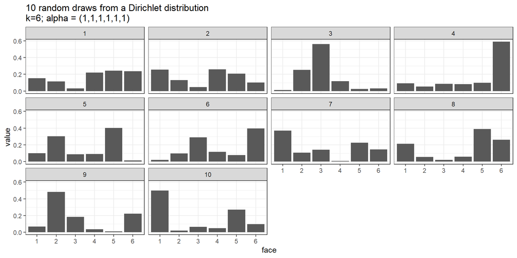

## The Dirichlet Distribution

- Low values of alpha will result in more variability
- Higher values of alpha will mean less variability

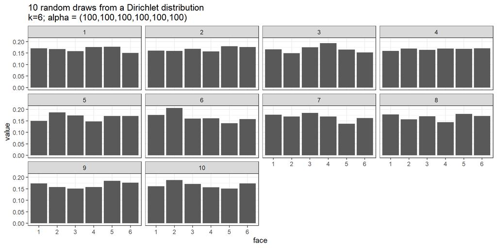

## The Dirichlet Distribution

- Low values of alpha will result in more variability
- Higher values of alpha will mean less variability
- Non-uniform values of alpha will mean a consistent bias favoring faces with higher values.

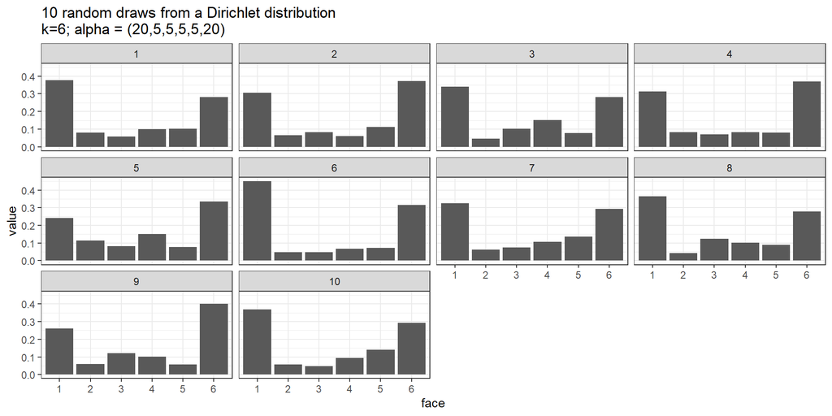

## Dirichlets in topic models

- LDA assumes that documents are generated by sampling from latent (unobserved) Dirichlet distributions. We’ll usually refer to these as phi ($\phi$) and theta ($\theta$)
- Our goal is to infer the properties of these distributions that maximizes the likelihood of observing our data.

## Topic-word distributions

- A “topic” in the context of topic modeling, is a Dirichlet distribution that generates words. The matrix of topic-word probabilities is often referred to as phi $\phi$
- Every word has a > 0 probability of occurring in every topic, but most topics will favor certain terms more than others.

| Topic | Word | Probability |
| --- | --- | --- |
| Topic 1 | postal | 0.04 |
|  | mail | 0.02 |
|  | branch | 0.01 |
| Topic 2 | gun | 0.04 |
|  | firearm | 0.02 |
|  | carry | 0.01 |
| Topic 3 | military | 0.04 |
|  | conflict | 0.02 |
|  | officer | 0.02 |

## Document-topic distributions

- Similarly, each “document” has its own latent Dirichlet distribution that determines the probability of a topic occurring in that document. All topics have a > 0 probability of occurring in all documents, but most will be weighted towards one or two topics.

| Document ID | Topic 1 | Topic 2 | Topic 3 |
| --- | --- | --- | --- |
| Document 1 | 0.75 | 0.15 | 0.10 |
| Document 2 | 0.10 | 0.80 | 0.10 |
| Document 3 | 0.30 | 0.05 | 0.65 |

## The LDA Generative Model

$k$ represents the number of topics. $\alpha$ and $\beta$ are “hyperparameters” that control the uniformity of the Dirichlet distributions. Everything else is inferred from the data.

## The LDA Generative Model

In other words, the theoretical model says I write documents by:

- sampling a topic from my document-topic distribution.
- sampling a word from my topic-word distribution.

## LDA inference

If the word *postal* is assigned to topic 1 in document 1, then I would look up:

- The probability of topic 1 in document 1: $p(\text{topic 1} | \theta_\text{document 1}) = .75$
- The probability of “postal” in topic 1: $p(\text{postal} | \phi_\text{topic 1}) = .04$
- Taking the product of these terms gives me: $.75 \times .04 = 0.03$

Doing this for the entire corpus and then multiplying* together gives me the total likelihood under a proposed $\theta$ and $\phi$

| Topic | Word | Probability |
| --- | --- | --- |
| Topic 1 | postal | 0.04 |
|  | mail | 0.02 |
|  | branch | 0.01 |

| Document ID | Topic 1 | Topic 2 | Topic 3 |
| --- | --- | --- | --- |
| Document 1 | 0.75 | 0.15 | 0.10 |

## LDA inference: practical considerations

- LDA models rely on iterative algorithms to maximize the likelihood of the documents (Gibbs sampling or Expectation Maximization)
- The main practical implication: models will take a while. Gibbs sampling is slower, but more reliable. EM is fast but sometimes fails to converge to the correct answer.
- As with K-means clustering: these approaches use a random initialization and then iteratively improve their guesses until convergence. So: the topic numbering can change if we don’t set a random number seed.

## What makes a good topic model?

A good topic model should:

- Ignore arbitrary features like document length.
- Make it easy to identify similar documents, even if they use different words to express the same idea.
- Allow for the possibility that a document has more than one topic.
- Generate interpret-able clusters of topics.

## Try it out

- Code for LDA is in part 3 of [the example code](https://raw.githubusercontent.com/Neilblund/GVPT628Fall2025/refs/heads/main/Week%2013/LDA_example.R).

## Variations on LDA

- One feature of LDA is that it’s relatively easy to extend the proposed generative model to incorporate additional information.
- Variations exist to account for document authorship, incorporate information about sequencing or dates, or pre-select tags for a subset of documents.

## Variations on LDA: Key-ATM

- Keyword assisted topic models (Eshima, Imai, and Sasaki 2024) allow users to specify some keyword topics that will be more associated with specific words.
- This involves adding separate parameters for keyword topics and keyword probabilities, but the general interpretation is the same.
- The authors further extend the model to allow document-level covariates to influence the probabilities of different topics.

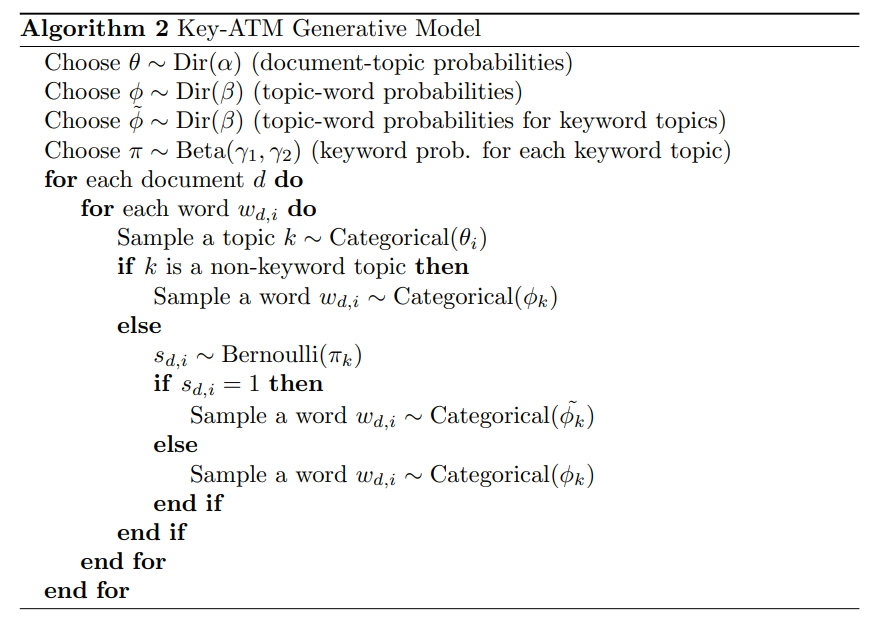

## Try it out

Code for the Key-ATM model (with covariates) is in part 4 of [the example code](https://raw.githubusercontent.com/Neilblund/GVPT628Fall2025/refs/heads/main/Week%2013/LDA_example.R).

# Alternatives to the bag-of-words approach

## Text Embeddings

The bag-of-words approach works surprisingly well. Especially when we have a lot of documents, but:

- learning from scratch is inefficient: a topic model needs hundreds of documents just to infer that “taxes” and “budgets” are related.
- including new terms requires us to essentially re-train a model.
- words have context-specific meanings that bag-of-words approaches can’t capture.

## Embedding models

- Models based on text-embeddings offer an alternative to the bag-of-words approach. Text embedding models convert raw text into a dense numeric vector where similar values indicate similar semantic relationships.

## Embedding models

You can think of assigning some numeric values to a list of terms that reflect their felinity, and adultness:

[output not shown]

Similar words would end up with similar “locations” in this space.

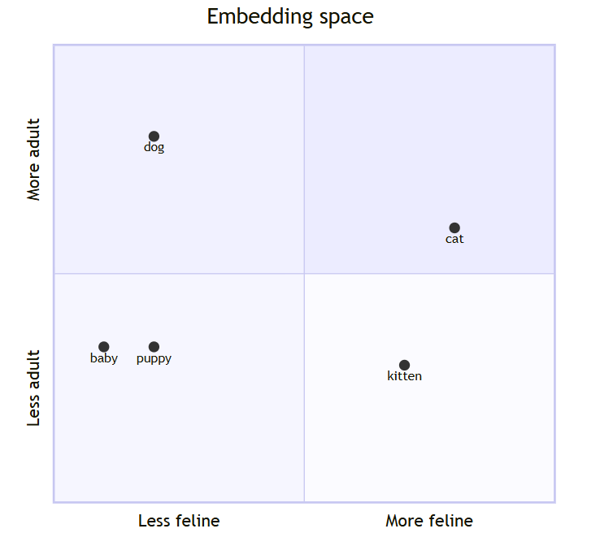

## Embedding models

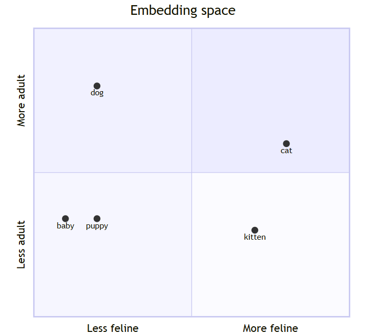

- Instead of a term-document-matrix, you could use the embedding values as inputs for a model, giving you a model pre-encodes things like synonymy.
- You can think of word embeddings as the result of an automated version of this process for lots of dimensions.

## Embedding models: inference

There are multiple methods for inferring these embeddings, but they all rely on the assumption that words with similar meanings will occur in similar contexts.

A tiny little ____ (baby, kitten, puppy, dog, cat)

The ____’s whiskers (baby, kitten, puppy, dog, cat)

I took my ____ to the pediatrician (baby, kitten, puppy, dog, cat)

I neutered my ____ (baby, kitten, puppy, dog, cat)

## Embedding models: Word2Vec

For instance, one early implementation relies on training a neural network to predict a held out word

> [The ____’s whiskers] (cat)

[figure not shown]

## Embedding models: Word2Vec

After training, the output layer is discarded and the projection layer weights are used for the embeddings.

[figure not shown]

Words that occur in similar contexts will end up with similar values in the projection layer.

## Embedding models: Word2Vec

- Note that these embeddings are kind of a supervised model, but the “labels” come from the texts themselves. So, the training data is just lots and lots of words.
- Embeddings can be pre-trained on a huge amount of text and then re-used or adapted into a new context (transfer learning)

## Embedding models: Sentences and Documents

- Newer models have extended this basic logic to entire sentences or documents, and also encode things like context and word order.
- Pretrained models like [BERT](https://huggingface.co/google-bert/bert-base-uncased) are built to be easily generalizable to new contexts.

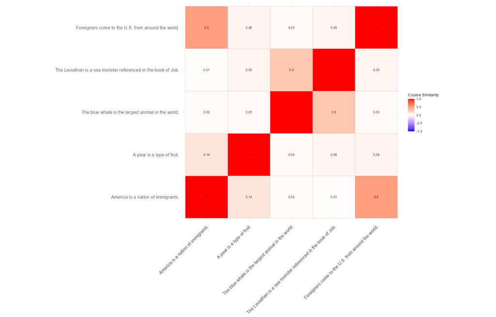

## Back to topics: BERTopic

- BERTopic is a topic modeling approach that uses clustering and dimensionality reduction techniques on sentence embeddings to model topics.
- (it’s really one of several variations on this theme, but it happens to have an accessible Python package)

[figure not shown]

## Try it out

Example code for [embedding a sentence and using BERTopic is here](https://raw.githubusercontent.com/Neilblund/GVPT628Fall2025/refs/heads/main/Week%2013/embed_and_bertopic.R).

## References

Eshima, Shusei, Kosuke Imai, and Tomoya Sasaki. 2024. “Keyword-Assisted Topic Models.” *American Journal of Political Science* 68 (2): 730–50.

Koljonen, Juha, Veikko Isotalo, Pertti Ahonen, and Mikko Mattila. 2022. “Comparing Computational and Non-Computational Methods in Party Position Estimation: Finland, 2003–2019.” *Party Politics* 28 (2): 306–17.

Roberts, Margaret E, Brandon M Stewart, Dustin Tingley, Christopher Lucas, Jetson Leder-Luis, Shana Kushner Gadarian, Bethany Albertson, and David G Rand. 2014. “Structural Topic Models for Open-Ended Survey Responses.” *American Journal of Political Science* 58 (4): 1064–82.

Watanabe, Kohei. 2021. “Latent Semantic Scaling: A Semisupervised Text Analysis Technique for New Domains and Languages.” *Communication Methods and Measures* 15 (2): 81–102.